# IODS course project

Laura Venieri

# Introduction to open data science

In the course *Introduction to open data science* we will learn to analyze, interpret and visualize data using open research tools (**R**, **R Studio**, **R markdown** and **GitHub**) with open data.

This is my [GitHub repository](https://github.com/laurveni/IODS-project).

# Regression and model validation

The data set we are using was collected in 2014 for an international survey of Approaches to Learning.

This is the dimension of the data set.

```
## [1] 166   7
```

This is the structure.

```
## 'data.frame':    166 obs. of  7 variables:
##  $ gender  : Factor w/ 2 levels "F","M": 1 2 1 2 2 1 2 1 2 1 ...
##  $ age     : int  53 55 49 53 49 38 50 37 37 42 ...
##  $ attitude: int  37 31 25 35 37 38 35 29 38 21 ...
##  $ deep    : num  3.58 2.92 3.5 3.5 3.67 ...
##  $ stra    : num  3.38 2.75 3.62 3.12 3.62 ...
##  $ surf    : num  2.58 3.17 2.25 2.25 2.83 ...
##  $ points  : int  25 12 24 10 22 21 21 31 24 26 ...
```

You can find more information about the data [here](http://www.helsinki.fi/~kvehkala/JYTmooc/JYTOPKYS3-meta.txt).

Here is a graphical overview of the data.

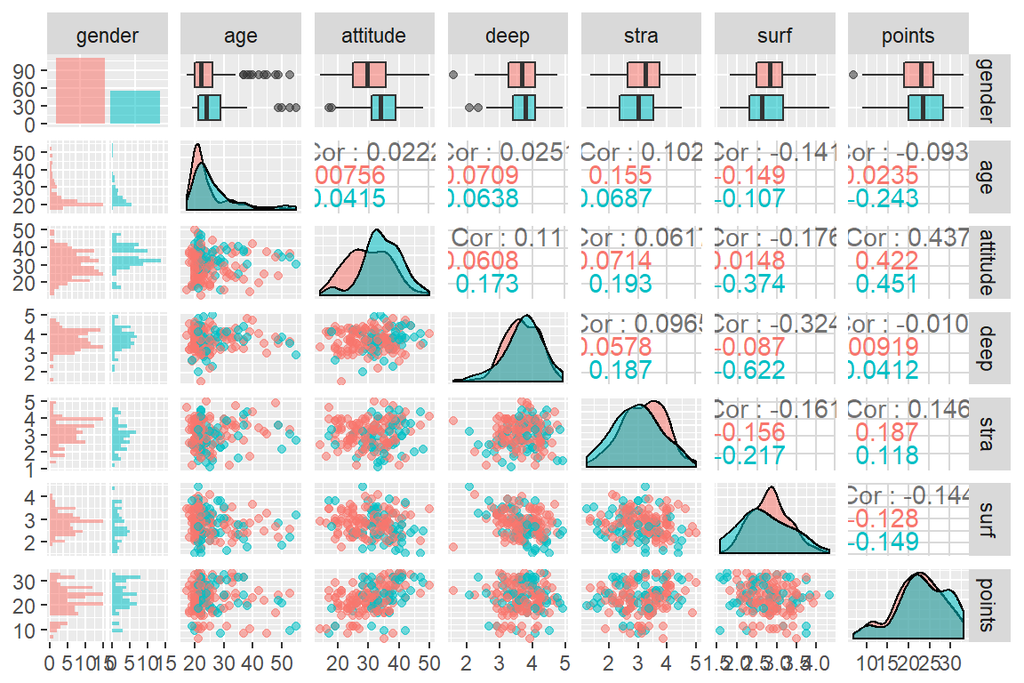

Since the three variables having the highest (absolute) correlation with exam points are attitude, stra and surf, we fit a regression model with points as the target and attitude, stra and surf as explanantory variables. Here is a summary of the model.

```
##
## Call:
## lm(formula = points ~ attitude + stra + surf, data = learning2014)
##
## Residuals:
##      Min       1Q   Median       3Q      Max
## -17.1550  -3.4346   0.5156   3.6401  10.8952
##
## Coefficients:
##             Estimate Std. Error t value Pr(>|t|)
## (Intercept) 11.01711    3.68375   2.991  0.00322 **
## attitude     0.33952    0.05741   5.913 1.93e-08 ***
## stra         0.85313    0.54159   1.575  0.11716
## surf        -0.58607    0.80138  -0.731  0.46563
## ---
## Signif. codes:  0 '***' 0.001 '**' 0.01 '*' 0.05 '.' 0.1 ' ' 1
##
## Residual standard error: 5.296 on 162 degrees of freedom
## Multiple R-squared:  0.2074, Adjusted R-squared:  0.1927
## F-statistic: 14.13 on 3 and 162 DF,  p-value: 3.156e-08
```

```
##
## Call:
## lm(formula = points ~ attitude + stra, data = learning2014)
##
## Residuals:
##      Min       1Q   Median       3Q      Max
## -17.6436  -3.3113   0.5575   3.7928  10.9295
##
## Coefficients:
##             Estimate Std. Error t value Pr(>|t|)
## (Intercept)  8.97290    2.39591   3.745  0.00025 ***
## attitude     0.34658    0.05652   6.132 6.31e-09 ***
## stra         0.91365    0.53447   1.709  0.08927 .
## ---
## Signif. codes:  0 '***' 0.001 '**' 0.01 '*' 0.05 '.' 0.1 ' ' 1
##
## Residual standard error: 5.289 on 163 degrees of freedom
## Multiple R-squared:  0.2048, Adjusted R-squared:  0.1951
## F-statistic: 20.99 on 2 and 163 DF,  p-value: 7.734e-09
```

Let us now look at the following diagnostic plots: Residuals vs Fitted values, Normal QQ-plot and Residuals vs Leverage.

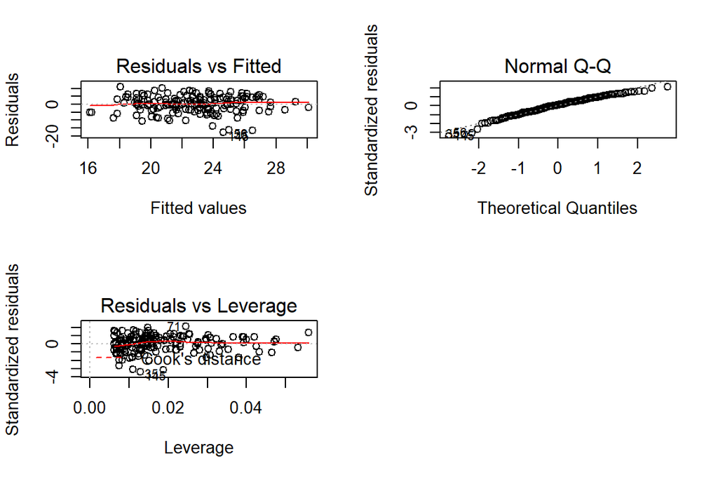

In the Residuals vs Fitted plot the points are quite scattered so the size of the errors does not seem to depend on the explanatory variable. This means that the assumption that the variance is constant is reasonable. In the Normal QQ-plot we can observe that there is a quite good fit to the line so the assumption that the errors of the model are normally distributed is reasonable. The Residuals vs Leverage plot shows that all values have low leverages so there is no observation with unusually high impact.

# Logistic Regression

The joined data set that we will use combines two data sets (student-mat and student-por) that approach student achievement in secondary education of two Portuguese schools. [Here](https://archive.ics.uci.edu/ml/datasets/Student+Performance) you can find more information about the data. We made the following adjustments:

- the variables not used for joining the two data have been combined by averaging (including the grade variables);
- ‘alc_use’ is the average of ‘Dalc’ and ‘Walc’;
- ‘high_use’ is TRUE if ‘alc_use’ is higher than 2 and FALSE otherwise.

This is the dimension of the data set.

```r
alc <- read.csv(file="data/student-alc.csv")
dim(alc)
```

```
## [1] 382  35
```

This is the structure.

```r
str(alc)
```

```
## 'data.frame':    382 obs. of  35 variables:
##  $ school    : Factor w/ 2 levels "GP","MS": 1 1 1 1 1 1 1 1 1 1 ...
##  $ sex       : Factor w/ 2 levels "F","M": 1 1 1 1 1 2 2 1 2 2 ...
##  $ age       : int  18 17 15 15 16 16 16 17 15 15 ...
##  $ address   : Factor w/ 2 levels "R","U": 2 2 2 2 2 2 2 2 2 2 ...
##  $ famsize   : Factor w/ 2 levels "GT3","LE3": 1 1 2 1 1 2 2 1 2 1 ...
##  $ Pstatus   : Factor w/ 2 levels "A","T": 1 2 2 2 2 2 2 1 1 2 ...
##  $ Medu      : int  4 1 1 4 3 4 2 4 3 3 ...
##  $ Fedu      : int  4 1 1 2 3 3 2 4 2 4 ...
##  $ Mjob      : Factor w/ 5 levels "at_home","health",..: 1 1 1 2 3 4 3 3 4 3 ...
##  $ Fjob      : Factor w/ 5 levels "at_home","health",..: 5 3 3 4 3 3 3 5 3 3 ...
##  $ reason    : Factor w/ 4 levels "course","home",..: 1 1 3 2 2 4 2 2 2 2 ...
##  $ nursery   : Factor w/ 2 levels "no","yes": 2 1 2 2 2 2 2 2 2 2 ...
##  $ internet  : Factor w/ 2 levels "no","yes": 1 2 2 2 1 2 2 1 2 2 ...
##  $ guardian  : Factor w/ 3 levels "father","mother",..: 2 1 2 2 1 2 2 2 2 2 ...
```

[output cut: 21 more lines]

Let us look at the distributions of the variables.

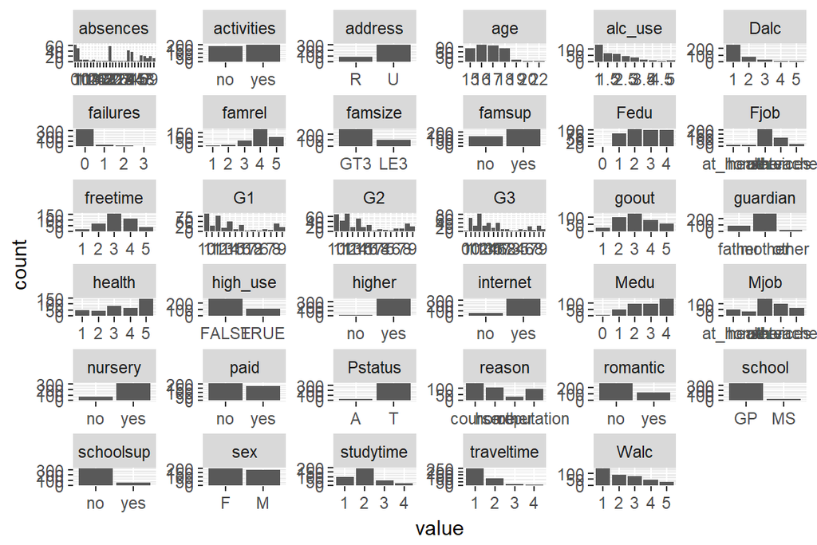

```r
library(tidyr); library(dplyr); library(ggplot2)
gather(alc) %>% ggplot(aes(value)) + facet_wrap("key", scales = "free")+geom_bar()
```

We make the hypothesis that there is a relationship between alcohol consumption (high_use) and the final grade (G3): high grades correspond to low alcohol consumption and low grades to high alcohol consumption. Similarly, we make the hypthesis of a correlation between a high number of classes failed (failures) and high alcohol consumption. Also a high number of absences from school could correspond to a high alcohol consumption. Moreover, it seems plausible that male students consume more alcohol than females.

Let us look at a bar plot of high_use by sex.

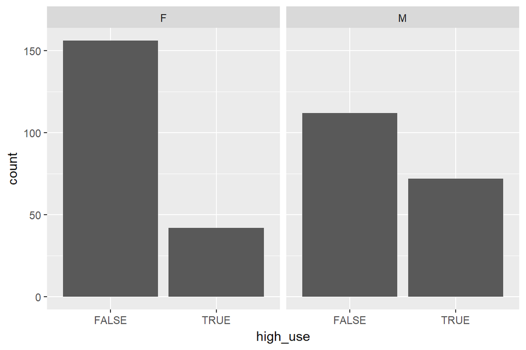

```r
g2 <- ggplot(data = alc, aes(x=high_use))
g2+ geom_bar()+ facet_wrap("sex")
```

Looking at this table

```r
alc %>% group_by(sex,high_use) %>% summarise(count = n(),mean_grade=mean(G3))
```

```
## # A tibble: 4 x 4
## # Groups:   sex [?]
##      sex high_use count mean_grade
##   <fctr>    <lgl> <int>      <dbl>
## 1      F    FALSE   156   11.39744
## 2      F     TRUE    42   11.71429
## 3      M    FALSE   112   12.20536
## 4      M     TRUE    72   10.27778
```

and this box-plot,

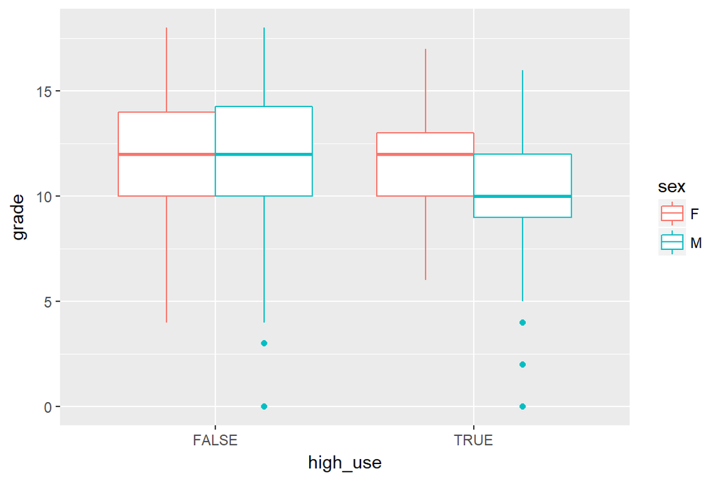

```r
g1 <- ggplot(alc, aes(x = high_use, y = G3,col=sex))
g1 + geom_boxplot() + ylab("grade")
```

it appears to be reasonable that for male students low alcohol consumption corresponds to higher grades, whereas for female students it is not so clear.

Let us take a look at the relationship between failures and high_use. The variable failures takes value n if n is the number of failed classes and n is at most 3, whereas it takes the value 4 if the number of failed classes is at least 4.

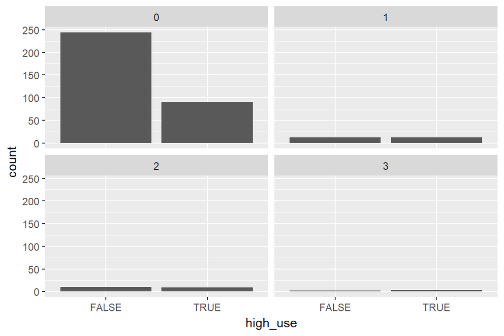

```r
g2 <- ggplot(data = alc, aes(x=high_use))
g2+ geom_bar()+ facet_wrap("failures")
```

More than half of the students who have not failed any class have low alcohol consumption so our hypothesis seems reasonable.

The following box-plot suggests that a higher number of school absences corresponds to a higher alcohol consumption.

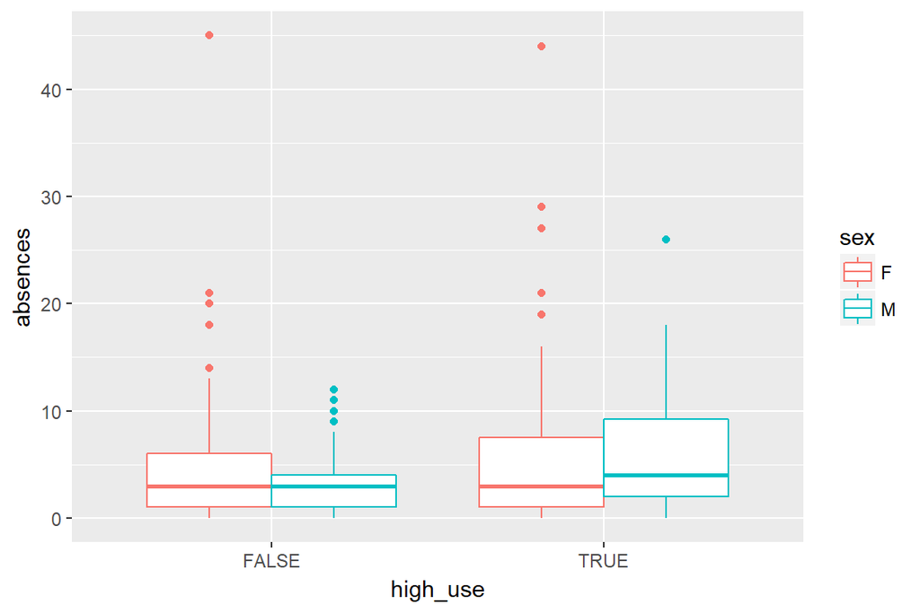

```r
g2 <- ggplot(alc,aes(x=high_use,y=absences,col=sex))
g2+geom_boxplot()
```

We now fit a logistic regression model with high_use as the target variable and the final grade (G3), failures, absences and sex as explanatory variables.

```r
m <- glm(high_use ~ G3 + absences+sex+failures, data = alc, family = "binomial")
summary(m)
```

```
##
## Call:
## glm(formula = high_use ~ G3 + absences + sex + failures, family = "binomial",
##     data = alc)
##
## Deviance Residuals:
##     Min       1Q   Median       3Q      Max
## -2.1891  -0.8373  -0.6049   1.0357   2.1337
##
## Coefficients:
##             Estimate Std. Error z value Pr(>|z|)
## (Intercept) -1.29860    0.50329  -2.580  0.00987 **
## G3          -0.05115    0.03865  -1.323  0.18571
## absences     0.09135    0.02293   3.983 6.81e-05 ***
## sexM         0.95321    0.24278   3.926 8.63e-05 ***
## failures     0.34596    0.20496   1.688  0.09142 .
## ---
## Signif. codes:  0 '***' 0.001 '**' 0.01 '*' 0.05 '.' 0.1 ' ' 1
##
## (Dispersion parameter for binomial family taken to be 1)
##
##     Null deviance: 465.68  on 381  degrees of freedom
## Residual deviance: 422.65  on 377  degrees of freedom
## AIC: 432.65
##
## Number of Fisher Scoring iterations: 4
```

```r
m2 <- glm(high_use ~ failures + absences + sex, data = alc, family = "binomial")
summary(m2)
```

```
##
## Call:
## glm(formula = high_use ~ failures + absences + sex, family = "binomial",
##     data = alc)
##
## Deviance Residuals:
##     Min       1Q   Median       3Q      Max
## -2.1855  -0.8371  -0.6000   1.1020   2.0209
##
## Coefficients:
##             Estimate Std. Error z value Pr(>|z|)
## (Intercept) -1.90297    0.22626  -8.411  < 2e-16 ***
## failures     0.45082    0.18992   2.374 0.017611 *
## absences     0.09322    0.02295   4.063 4.85e-05 ***
## sexM         0.94117    0.24200   3.889 0.000101 ***
## ---
## Signif. codes:  0 '***' 0.001 '**' 0.01 '*' 0.05 '.' 0.1 ' ' 1
##
## (Dispersion parameter for binomial family taken to be 1)
##
##     Null deviance: 465.68  on 381  degrees of freedom
## Residual deviance: 424.40  on 378  degrees of freedom
## AIC: 432.4
##
## Number of Fisher Scoring iterations: 4
```

Let us take a look at how well the second model can make predictions. Here is a table of predictions versus the actual values of the variable high_use.

```r
probabilities <- predict(m2, type = "response")

# add the predicted probabilities to 'alc'
alc <- mutate(alc, probability = probabilities)

# use the probabilities to make a prediction of high_use
alc <- mutate(alc, prediction = probability>0.5)

# tabulate the target variable versus the predictions
table(high_use = alc$high_use, prediction = alc$prediction)
```

```
##         prediction
## high_use FALSE TRUE
##    FALSE   259    9
##    TRUE     84   30
```

And here is the avarage number of wrong predictions in the training data.

```r
# define a loss function (mean prediction error)
loss_func <- function(class, prob) {
  n_wrong <- abs(class - prob) > 0.5
  mean(n_wrong)
}

# call loss_func to compute the average number of wrong predictions in the (training) data
loss_func(class = alc$high_use, prob = alc$probability)
```

```
## [1] 0.2434555
```

If we assume that the probability of high_use is zero for each individual (so we guess that high_use is always FALSE) then the avarage number of wrong predictions is

```r
loss_func(class = alc$high_use, prob = 0)
```

```
## [1] 0.2984293
```

which is a bit higher than that of our model. Thus our model can predict a bit better than a simple guessing strategy (even if not much better).

Let us now perform a 10-fold cross-validation on the model. The avarage number of wrong predictions in the cross validation is

```r
library(boot)
cv <- cv.glm(data = alc, cost = loss_func, glmfit = m, K = 10)

# average number of wrong predictions in the cross validation
cv$delta[1]
```

```
## [1] 0.2670157
```